# Tarea 2 — Respuesta al impulso

#### Integrantes: Tomás Alvarado - Miguel Baeza

#### Profesores: Víctor Poblete - Felipe Figueroa

#### Asignatura: ACUS09 Procesamiento digital de señales

#### Fecha de entrega: Jueves 30 de abril

# Introducción

Esta página web fue creada como registro del proceso y resultados de la Tarea 2 de la asignatura ACUS099: Procesamiento digital de señales. La cual consistía registrar la respuesta de impulso de dos recintos de distintas diminsiones y usos, además, se hizo también en la Cámara Reverberante del campus Miraflores de la Universidad Austral de Chile.

Todo esto para convolucionar la respuesta de los distintos archivos de audio grabados en estos espacios. Para este trabajo, se usaron dos grabaciones tomadas en la Cámara Anecoica del campus de Miraflores, siendo el primer audio el coro de la canción "Camara Lenta" de Javiera Mena (2006) de forma hablada por Tomás Alvarado. El segundo audio es parte del solo de guitarra de la cancion "Buddy Holly" de la banda Weezer (1994) interpretado en una melódica por Miguel Baeza.

Los dos recintos en donde se tomaron los registros fueron el Laboratorio A de fisica del edificio 6000 y uno de los cubiculos del edificio 9000, ambos parte del campus miraflores.

# Convolución

La convolución es una operación matemática que permite la combinación de una señal de entrada con la respuesta de impulso de una sala, esto para obtener una señal de salida con las características del recinto. Lo cual permite simular cómo se escucharía el sonido sin la necesidad de grabar este mismo en ese lugar, pudiendo así identificar las cualidades acústicas de la sala como lo sería por ejemplo, la reverberación.

# Equipo y procedimiento

El equipo utilizado para los registros fue un microfono Behringer ECM 8000 con su pedestal, una interzar de audio Focusrite Scarlett 2i4, cable XLR (para conectar el micrófono a la interfaz), un pc con Reaper instalado, una huincha de 1,20[m] y una claqueta. Lo primero que se hizo fue grabar los audios en la Camara Anecoica que posteriormente, después de eso se fue a la Camara Reverberante para tomar las respuestas de impulso con la claqueta, finalizando con el laboratorio y el cubículo tambien tomados con la claqueta. La huincha se usó para cumplir con la normativa ISO 3382 en las distintos registros de respuesta de impulso.

[figure not shown]

# Desarrollo

### Importaciones de Librerias

```python
from pathlib import Path
import numpy as np
import matplotlib.pyplot as plt
import soundfile as sf
import librosa
from scipy.signal import fftconvolve
from IPython.display import Audio, display
```

#### Cargar Audio de voz, frecuencia de muestreo y gráfico

```
Ruta voz: ..\assets\audio\Voz.wav
Frecuencia de muestreo voz: 48000
Voz original:
```

[interactive chart not shown]

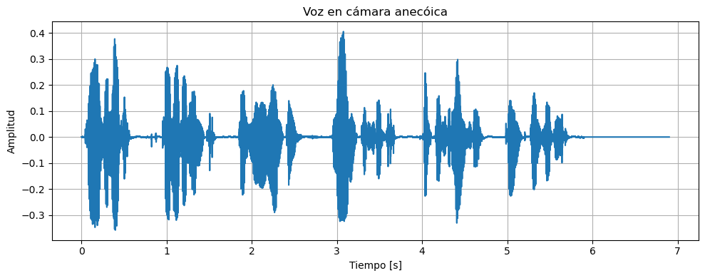

```python
ruta_voz = Path("../assets/audio/Voz.wav")

print("Ruta voz:", ruta_voz)
assert ruta_voz.exists(), f"No existe el archivo: {ruta_voz}"

voz, fs_voz = sf.read(ruta_voz)
print("Frecuencia de muestreo voz:", fs_voz)

print("Voz original:")
display(Audio(voz, rate=fs_voz))

t_voz = np.arange(len(voz)) / fs_voz
plt.figure(figsize=(10, 4))
plt.plot(t_voz, voz)
plt.title("Voz en cámara anecóica")
plt.xlabel("Tiempo [s]")
plt.ylabel("Amplitud")
plt.grid()
plt.tight_layout()
plt.show()
```

# Convolución de voz

### 1. Camara Reverberante

[figure not shown]

```
IR Cámara Reverberante:
```

[interactive chart not shown]

```
Voz + Reverberante:
```

[interactive chart not shown]

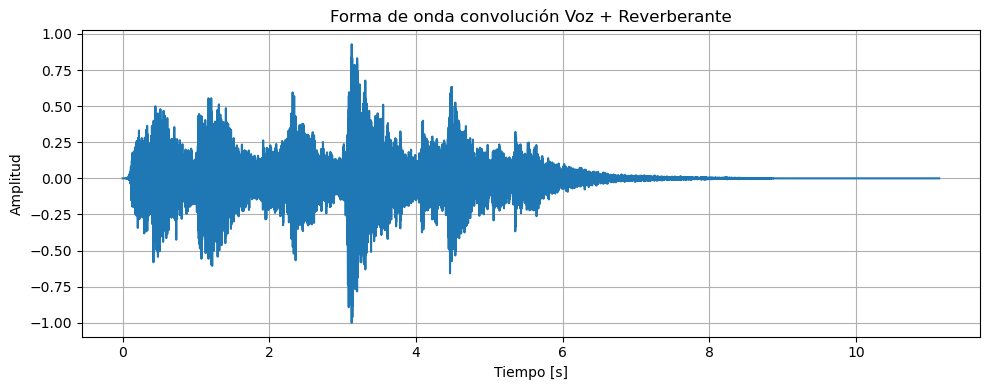

```python
# Cargamos la respuesta de impulso
ruta_ir1 = Path("../assets/audio/IR_Reverberante.wav")

ir1, fs_ir1 = sf.read(ruta_ir1)

# Realizamos la convolución

y = fftconvolve(voz, ir1, mode="full")

if np.max(np.abs(y)) > 0:
    y = y / np.max(np.abs(y))

print("IR Cámara Reverberante:")
display(Audio(ir1, rate=fs_ir1))

print("Voz + Reverberante:")
display(Audio(y, rate=fs_voz))

t_voz = np.arange(len(voz)) / fs_voz
t_ir1 = np.arange(len(ir)) / fs_ir1
t_y = np.arange(len(y)) / fs_voz

plt.figure(figsize=(10, 4))
plt.plot(t_y, y)
plt.title("Forma de onda convolución Voz + Reverberante")
plt.xlabel("Tiempo [s]")
plt.ylabel("Amplitud")
plt.grid()
plt.tight_layout()
plt.show()
```

### 2. Lab A, Edificio 6000

```
IR Lab A:
```

[interactive chart not shown]

```
Voz + Lab A:
```

[interactive chart not shown]

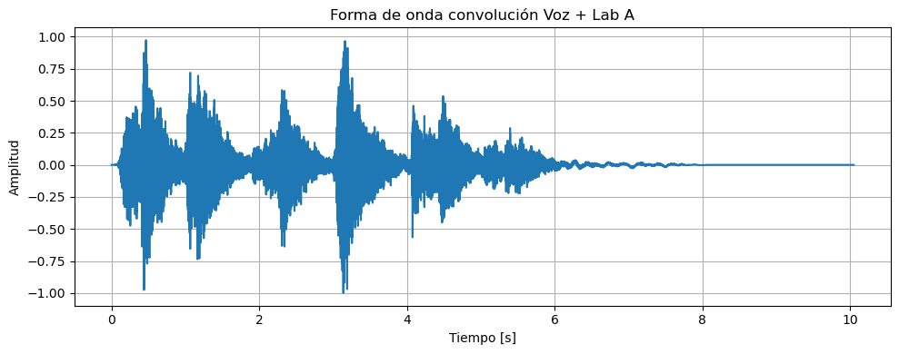

```python
ruta_ir2 = Path("../assets/audio/IR_LabA.wav")

ir2, fs_ir2 = sf.read(ruta_ir2)

y = fftconvolve(voz, ir2, mode="full")

if np.max(np.abs(y)) > 0:
    y = y / np.max(np.abs(y))

print("IR Lab A:")
display(Audio(ir2, rate=fs_ir2))

print("Voz + Lab A:")
display(Audio(y, rate=fs_voz))

t_voz = np.arange(len(voz)) / fs_voz
t_ir2 = np.arange(len(ir)) / fs_ir2
t_y = np.arange(len(y)) / fs_voz

plt.figure(figsize=(10, 4))
plt.plot(t_y, y)
plt.title("Forma de onda convolución Voz + Lab A")
plt.xlabel("Tiempo [s]")
plt.ylabel("Amplitud")
plt.grid()
plt.tight_layout()
plt.show()
```

### 3. Cubiculo, Edificio 9000

```
IR Cubículo:
```

[interactive chart not shown]

```
Voz + Cubículo:
```

[interactive chart not shown]

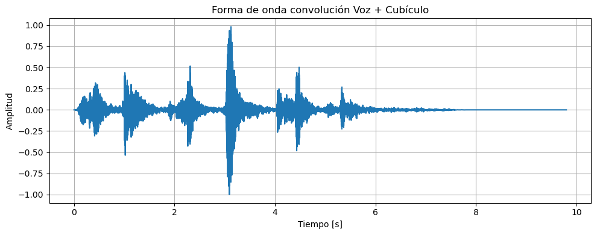

```python
ruta_ir3 = Path("../assets/audio/IR_Cubiculo.wav")

ir3, fs_ir3 = sf.read(ruta_ir3)

y = fftconvolve(voz, ir3, mode="full")

if np.max(np.abs(y)) > 0:
    y = y / np.max(np.abs(y))

print("IR Cubículo:")
display(Audio(ir3, rate=fs_ir3))

print("Voz + Cubículo:")
display(Audio(y, rate=fs_voz))

t_voz = np.arange(len(voz)) / fs_voz
t_ir3 = np.arange(len(ir)) / fs_ir3
t_y = np.arange(len(y)) / fs_voz

plt.figure(figsize=(10, 4))
plt.plot(t_y, y)
plt.title("Forma de onda convolución Voz + Cubículo")
plt.xlabel("Tiempo [s]")
plt.ylabel("Amplitud")
plt.grid()
plt.tight_layout()
plt.show()
```

# Convolución de melódica

```
Ruta melodica: ..\assets\audio\melodica.wav
Frecuencia de muestreo melodica: 48000
Melodica original:
```

[interactive chart not shown]

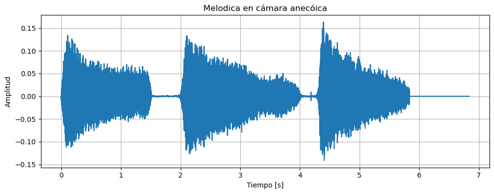

```python
ruta_melodica = Path("../assets/audio/melodica.wav")

print("Ruta melodica:", ruta_melodica)
assert ruta_melodica.exists(), f"No existe el archivo: {ruta_melodica}"

melodica, fs_melodica = sf.read(ruta_melodica)
print("Frecuencia de muestreo melodica:", fs_melodica)

print("Melodica original:")
display(Audio(melodica, rate=fs_melodica))

t_melodica = np.arange(len(melodica)) / fs_melodica
plt.figure(figsize=(10, 4))
plt.plot(t_melodica, melodica)
plt.title("Melodica en cámara anecóica")
plt.xlabel("Tiempo [s]")
plt.ylabel("Amplitud")
plt.grid()
plt.tight_layout()
plt.show()
```

## Repetimos las convoluciones

### 1. Cámara Reverberante

```
Melódica + Reverberante:
```

[interactive chart not shown]

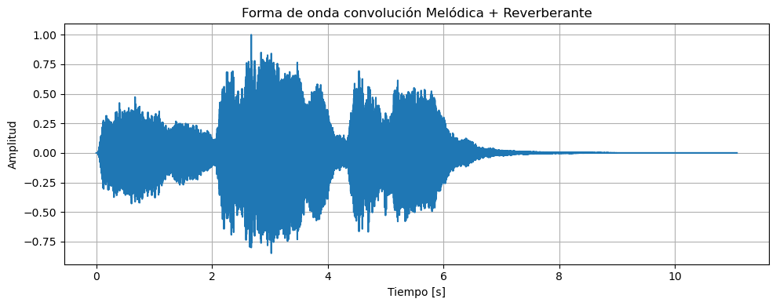

```python
y = fftconvolve(melodica, ir1, mode="full")

if np.max(np.abs(y)) > 0:
    y = y / np.max(np.abs(y))

print("Melódica + Reverberante:")
display(Audio(y, rate=fs_melodica))

t_melodica = np.arange(len(melodica)) / fs_melodica
t_ir1 = np.arange(len(ir)) / fs_ir1
t_y = np.arange(len(y)) / fs_melodica

plt.figure(figsize=(10, 4))
plt.plot(t_y, y)
plt.title("Forma de onda convolución Melódica + Reverberante")
plt.xlabel("Tiempo [s]")
plt.ylabel("Amplitud")
plt.grid()
plt.tight_layout()
plt.show()
```

### 2. Lab A, Edificio 6000

```
Melódica + Lab A:
```

[interactive chart not shown]

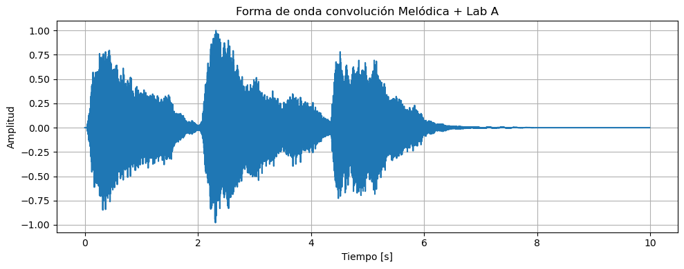

```python
y = fftconvolve(melodica, ir2, mode="full")

if np.max(np.abs(y)) > 0:
    y = y / np.max(np.abs(y))

print("Melódica + Lab A:")
display(Audio(y, rate=fs_melodica))

t_melodica = np.arange(len(melodica)) / fs_melodica
t_ir2 = np.arange(len(ir)) / fs_ir2
t_y = np.arange(len(y)) / fs_melodica

plt.figure(figsize=(10, 4))
plt.plot(t_y, y)
plt.title("Forma de onda convolución Melódica + Lab A")
plt.xlabel("Tiempo [s]")
plt.ylabel("Amplitud")
plt.grid()
plt.tight_layout()
plt.show()
```

### 3. Cubículo, Edificio 9000

```
Melódica + Cubiculo:
```

[interactive chart not shown]

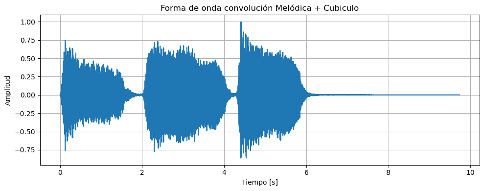

```python
y = fftconvolve(melodica, ir3, mode="full")

if np.max(np.abs(y)) > 0:
    y = y / np.max(np.abs(y))

print("Melódica + Cubiculo:")
display(Audio(y, rate=fs_melodica))

t_melodica = np.arange(len(melodica)) / fs_melodica
t_ir3 = np.arange(len(ir)) / fs_ir3
t_y = np.arange(len(y)) / fs_melodica

plt.figure(figsize=(10, 4))
plt.plot(t_y, y)
plt.title("Forma de onda convolución Melódica + Cubiculo")
plt.xlabel("Tiempo [s]")
plt.ylabel("Amplitud")
plt.grid()
plt.tight_layout()
plt.show()
```

# Conclusión

En conclusión se pudo realizar de forma experimental la convolución de salida de distintos audios de entrada, todo esto mediante a las respuestas de impulso obtenidas en las distintas salas, así pudiendo comprobar las distintas características de los espacios.